# Probability Distributions and Bar Plots

## Finished!

[figure not shown]

```r
p
```

## Building on the boxplot

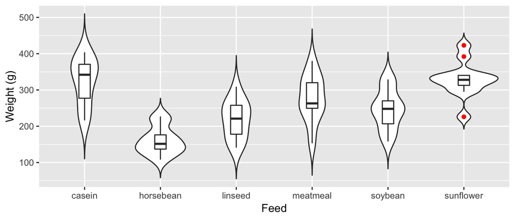

## Multiple `geom`s

- Last week we introduced `geom_violin()` and `geom_jitter()`
- Sometimes boxplots can be improved by adding additional representations of data
- Boxplot + jitter plot shows boxplot info plus the actual data
- Boxplot + violin plot is nice when there are many data points

```r
p2 <- ggplot(chickwts, aes(x = feed, y = weight)) +
  labs(x = "Feed", y = "Weight (g)")
```

## Boxplot + jitter

- Nice when the number of points is small

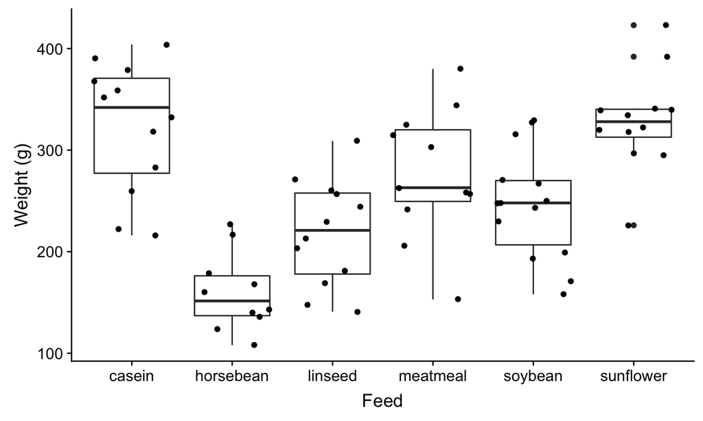

```r
p2 + geom_boxplot() + geom_jitter()
```

## Making adjustments

- make points transparent with `alpha =`
- make jitter narrower with `width =`
- change boxplot outlier points so they look different than data

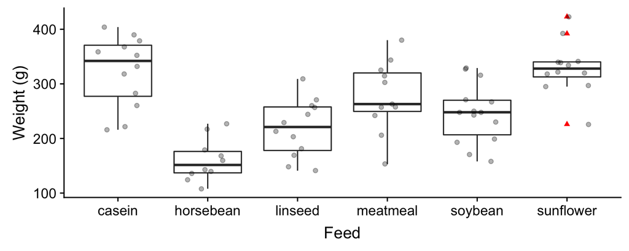

```r
p2 + geom_boxplot(outlier.color = "red", outlier.shape = "triangle") +
  geom_jitter(width = 0.25, alpha = 0.3)
```

## Order of `geom` matters

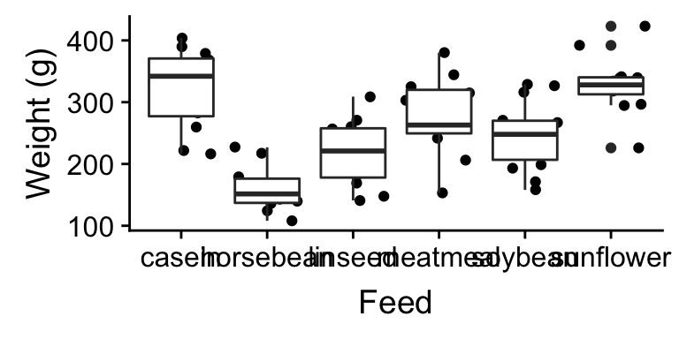

```r
p2 + geom_jitter() + geom_boxplot()
```

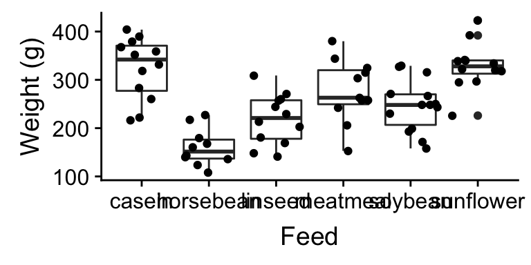

```r
p2 + geom_boxplot() + geom_jitter()
```

## Boxplot + violin

- Adjust boxplot width to fit inside violins
- Use `trim = FALSE` in `geom_violin()` to prevent it from truncating the ends

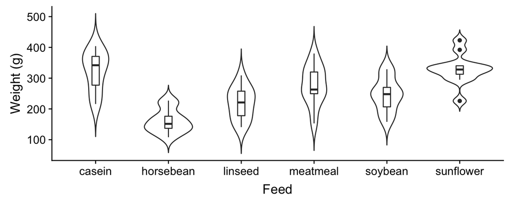

```r
p2 + geom_violin(trim = FALSE) +
     geom_boxplot(width = 0.1)
```